# TMDb Movies Data Set Analysis

#### Research Question 1 : How many movie in the dataset, and from which years are collected ?

```python
# Number of movies in the data set
# And the release year
print("Number of movies {} in the data set And the release year between {} & {}".
      format(df_original.shape[0],
             df_original.release_year.min(),
             df_original.release_year.max()
            )
     )
```

```
Number of movies 10866 in the data set And the release year between 1960 & 2015
```

### 2.2 - Data Cleaning (focusing on the budget & revenue & genres)

##### Removing unneeded columns from the dataset

id : it will not affect the analysis  
imdb_id : it will not affect the analysis  
homepage : it will not affect the analysis  
tagline : it will not affect the analysis  
keywords : it will not affect the analysis  
overview : it will not affect the analysis  
budget_adj : there is high corrolation between budget_adj and budget , so we will use budget  
revenue_adj : there is high corrolation between revenue_adj and revenue , so we will use revenue

```python
df_original.info()
```

```
<class 'pandas.core.frame.DataFrame'>
RangeIndex: 10866 entries, 0 to 10865
Data columns (total 21 columns):
id                      10866 non-null int64
imdb_id                 10856 non-null object
popularity              10866 non-null float64
budget                  10866 non-null int64
revenue                 10866 non-null int64
original_title          10866 non-null object
cast                    10790 non-null object
homepage                2936 non-null object
director                10822 non-null object
tagline                 8042 non-null object
keywords                9373 non-null object
overview                10862 non-null object
runtime                 10866 non-null int64
genres                  10843 non-null object
production_companies    9836 non-null object
release_date            10866 non-null object
vote_count              10866 non-null int64
vote_average            10866 non-null float64
release_year            10866 non-null int64
budget_adj              10866 non-null float64
revenue_adj             10866 non-null float64
dtypes: float64(4), int64(6), object(11)
memory usage: 1.7+ MB
```

```python
df = df_original.drop(["id",
                       "imdb_id",
                       "homepage",
                       "tagline",
                       "keywords",
                       "overview",
                       "budget_adj",
                       "revenue_adj"],
                      axis=1
                     )

df.info()
```

```
<class 'pandas.core.frame.DataFrame'>
RangeIndex: 10866 entries, 0 to 10865
Data columns (total 13 columns):
popularity              10866 non-null float64
budget                  10866 non-null int64
revenue                 10866 non-null int64
original_title          10866 non-null object
cast                    10790 non-null object
director                10822 non-null object
runtime                 10866 non-null int64
genres                  10843 non-null object
production_companies    9836 non-null object
release_date            10866 non-null object
vote_count              10866 non-null int64
vote_average            10866 non-null float64
release_year            10866 non-null int64
dtypes: float64(2), int64(5), object(6)
memory usage: 1.1+ MB
```

**Remove Duplicate Rows**

```python
#counting the duplicate elements
sum(df.duplicated())
```

```
1
```

```python
#drop duplicated row using 'drop_duplicates()' function
df=df.drop_duplicates()
df.shape
```

```
(10865, 13)
```

```python
# 1st row as example of the dataframe
df.head(1)
```

|  | popularity | budget | revenue | original_title | cast | director | runtime | genres | production_companies | release_date | vote_count | vote_average | release_year |
| --- | --- | --- | --- | --- | --- | --- | --- | --- | --- | --- | --- | --- | --- |
| 0 | 32.985763 | 150000000 | 1513528810 | Jurassic World | Chris Pratt\|Bryce Dallas Howard\|Irrfan Khan\|Vi... | Colin Trevorrow | 124 | Action\|Adventure\|Science Fiction\|Thriller | Universal Studios\|Amblin Entertainment\|Legenda... | 6/9/15 | 5562 | 6.5 | 2015 |

```python
df.isnull().sum()
```

```
popularity                 0
budget                     0
revenue                    0
original_title             0
cast                      76
director                  44
runtime                    0
genres                    23
production_companies    1030
release_date               0
vote_count                 0
vote_average               0
release_year               0
dtype: int64
```

# 3 - Exploratory Data Analysis

> Analysing the data frame

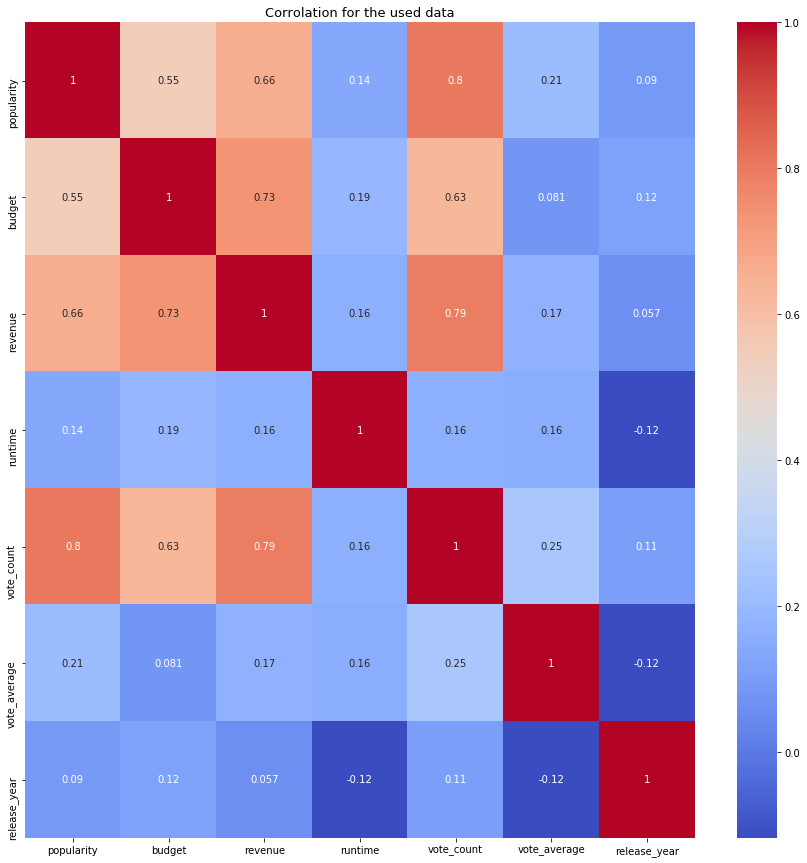

```python
# Correlation matrix
df_corr = df.corr()

plt.figure (figsize=(15,15))
ax = sns.heatmap(df_corr, annot = True, cmap = 'coolwarm')

ax.set_title("Corrolation for the used data",fontsize=13)
#ax.set_xlabel("Release Year",fontsize=12)
#ax.set_ylabel("Vote Average",fontsize=12)

plt.savefig('df_original corr.jpg')
```

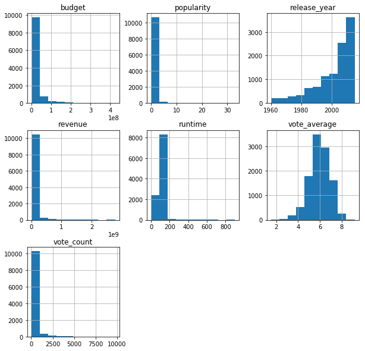

```python
df.hist(figsize=(10,10))


plt.savefig('General hist.jpg')
```

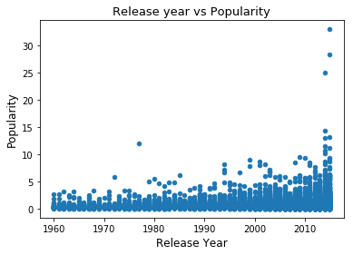

```python
ax = df.plot.scatter(x='release_year',y='popularity')
ax.set_title("Release year vs Popularity",fontsize=13)
ax.set_xlabel("Release Year",fontsize=12)
ax.set_ylabel("Popularity",fontsize=12)
plt.savefig('release_year vs popularity.jpg')
```

## 3.1 - Highest Movies

### 3.1.1 - Highest Movies (Revenue, Budget, Vote)

#### Research Question 2 : Which movie is the highest revenue?

```python
print("Highest revenue movie '{0}' with revenue {1}$ and budget {2}$".
      format(df.original_title[df.revenue == df.revenue.max()].values[0] ,
             df.revenue.max() ,
             df.budget[df.revenue == df.revenue.max()].values[0]
            )
     )

df[df.revenue == df.revenue.max()]
```

```
Highest revenue movie 'Avatar' with revenue 2781505847$ and budget 237000000$
```

|  | popularity | budget | revenue | original_title | cast | director | runtime | genres | production_companies | release_date | vote_count | vote_average | release_year |
| --- | --- | --- | --- | --- | --- | --- | --- | --- | --- | --- | --- | --- | --- |
| 1386 | 9.432768 | 237000000 | 2781505847 | Avatar | Sam Worthington\|Zoe Saldana\|Sigourney Weaver\|S... | James Cameron | 162 | Action\|Adventure\|Fantasy\|Science Fiction | Ingenious Film Partners\|Twentieth Century Fox ... | 12/10/09 | 8458 | 7.1 | 2009 |

#### Research Question 2 : Which movie is the highest budget?

```python
print("Highest budget movie '{0}' with budget {1}$ and revenue {2}$".
      format(df.original_title[df.budget == df.budget.max()].values[0] ,
             df.budget.max() ,
             df.revenue[df.budget == df.budget.max()].values[0]
            )
     )

df[df.budget == df.budget.max()]
```

```
Highest budget movie 'The Warrior's Way' with budget 425000000$ and revenue 11087569$
```

|  | popularity | budget | revenue | original_title | cast | director | runtime | genres | production_companies | release_date | vote_count | vote_average | release_year |
| --- | --- | --- | --- | --- | --- | --- | --- | --- | --- | --- | --- | --- | --- |
| 2244 | 0.25054 | 425000000 | 11087569 | The Warrior's Way | Kate Bosworth\|Jang Dong-gun\|Geoffrey Rush\|Dann... | Sngmoo Lee | 100 | Adventure\|Fantasy\|Action\|Western\|Thriller | Boram Entertainment Inc. | 12/2/10 | 74 | 6.4 | 2010 |

```python
print("Highest voted count movie '{}' with vote count {} and vote average {} and popularity {} ".
      format(
             df.original_title[df.vote_count == df.vote_count.max()].values[0] ,
             df.vote_count.max() ,
             df.vote_average[df.vote_count == df.vote_count.max()].values[0] ,
             df.popularity[df.vote_count == df.vote_count.max()].values[0]
            )
    )

df[df.vote_count == df.vote_count.max()]
```

```
Highest voted count movie 'Inception' with vote count 9767 and vote average 7.9 and popularity 9.363643
```

|  | popularity | budget | revenue | original_title | cast | director | runtime | genres | production_companies | release_date | vote_count | vote_average | release_year |
| --- | --- | --- | --- | --- | --- | --- | --- | --- | --- | --- | --- | --- | --- |
| 1919 | 9.363643 | 160000000 | 825500000 | Inception | Leonardo DiCaprio\|Joseph Gordon-Levitt\|Ellen P... | Christopher Nolan | 148 | Action\|Thriller\|Science Fiction\|Mystery\|Adventure | Legendary Pictures\|Warner Bros.\|Syncopy | 7/14/10 | 9767 | 7.9 | 2010 |

#### Research Question 4 : Which movie is the highest vote average & vote count?

#### and the relation between vote and population

```python
print("Highest voted average movie '{}' with vote average {} and vote count {}  and popularity {} ".
      format(
          df.original_title[df.vote_average == df.vote_average.max()].values[0] ,
          df.vote_average.max() ,
          df.vote_count[df.vote_average == df.vote_average.max()].values[0],
          df.popularity[df.vote_average == df.vote_average.max()].values[0]
      )
     )

df[df.vote_average == df.vote_average.max()]
```

```
Highest voted average movie 'The Story of Film: An Odyssey' with vote average 9.2 and vote count 14  and popularity 0.006925
```

|  | popularity | budget | revenue | original_title | cast | director | runtime | genres | production_companies | release_date | vote_count | vote_average | release_year |
| --- | --- | --- | --- | --- | --- | --- | --- | --- | --- | --- | --- | --- | --- |
| 3894 | 0.006925 | 0 | 0 | The Story of Film: An Odyssey | Mark Cousins\|Jean-Michel Frodon\|Cari Beauchamp... | Mark Cousins | 900 | Documentary | NaN | 9/3/11 | 14 | 9.2 | 2011 |

```python
print("Highest popularity movie '{}' with vote popularity {} and vote count {}  and vote average {} ".
      format(
          df.original_title[df.popularity == df.popularity.max()].values[0] ,
          df.popularity.max() ,
          df.vote_count[df.popularity == df.popularity.max()].values[0],
          df.vote_average[df.popularity == df.popularity.max()].values[0]
      )
     )
df[df.popularity == df.popularity.max()]
```

```
Highest popularity movie 'Jurassic World' with vote popularity 32.985763 and vote count 5562  and vote average 6.5
```

|  | popularity | budget | revenue | original_title | cast | director | runtime | genres | production_companies | release_date | vote_count | vote_average | release_year |
| --- | --- | --- | --- | --- | --- | --- | --- | --- | --- | --- | --- | --- | --- |
| 0 | 32.985763 | 150000000 | 1513528810 | Jurassic World | Chris Pratt\|Bryce Dallas Howard\|Irrfan Khan\|Vi... | Colin Trevorrow | 124 | Action\|Adventure\|Science Fiction\|Thriller | Universal Studios\|Amblin Entertainment\|Legenda... | 6/9/15 | 5562 | 6.5 | 2015 |

```
Text(0,0.5,'Vote Count')
```

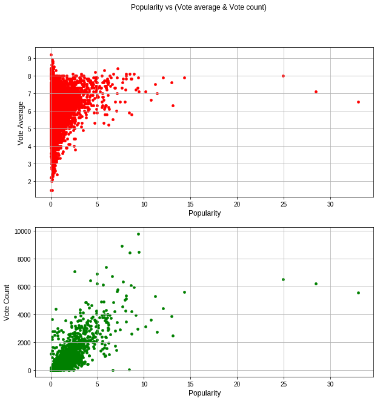

```python
fig, (ax1,ax2) = plt.subplots(2)
fig.suptitle('Popularity vs (Vote average & Vote count)')
plt.style.use('seaborn')

df.plot(kind='scatter',x='popularity',y='vote_average',color='r',ax=ax1,figsize=(10, 10))
ax1.set_xlabel("Popularity",fontsize=12)
ax1.set_ylabel("Vote Average",fontsize=12)


df.plot(kind='scatter',x='popularity',y='vote_count',color='g',ax=ax2,figsize=(10, 10))
ax2.set_xlabel("Popularity",fontsize=12)
ax2.set_ylabel("Vote Count",fontsize=12)
```

> From the previous analysis it is clear that :
> - there is corrolation between popularity and vote count

### 3.1.2 - The highest 15 revenue movies comparison

> Comparing (revenue,budget, vote_count,vote_average, release_year) for the highest 15 revenue movies with graph

##### the graph is saved as 'first 15th movies revenue compare.jpg'

```python
# function to add value labels
def addlabels(x,y):
    for i in range(len(x)):
        plt.text(x=i, y=y[i], s=y[i], ha = 'center',
                 bbox = dict(facecolor = 'red', alpha =.8))
def addlabels_1e0(x,y):
    for i in range(len(x)):
        M = float(y[i])
        M = M/1e0
        M = round(M,1)
        M = str(M)
        plt.text(x=i, y=y[i], s=M, ha = 'center',
                 bbox = dict(facecolor = 'red', alpha =.8))

def addlabels_1e9(x,y):
    for i in range(len(x)):
        M = float(y[i])
        M = M/1e9
        M = round(M,2)
        M = str(M)
        plt.text(x=i, y=y[i], s=M, ha = 'center',
                 bbox = dict(facecolor = 'red', alpha =.8))

def addlabels_1e8(x,y):
    for i in range(len(x)):
        M = float(y[i])
        M = M/1e8
        M = round(M,2)
        M = str(M)
        plt.text(x=i, y=y[i], s=M, ha = 'center',
                 bbox = dict(facecolor = 'red', alpha =.8))
```

```python
df_sorted = df.sort_values(by="revenue",ascending=False)
df_sorted[0:15].describe()
```

|  | popularity | budget | revenue | runtime | vote_count | vote_average | release_year |
| --- | --- | --- | --- | --- | --- | --- | --- |
| count | 15.000000 | 1.500000e+01 | 1.500000e+01 | 15.000000 | 15.000000 | 15.000000 | 15.000000 |
| mean | 7.977473 | 1.691333e+08 | 1.471385e+09 | 140.133333 | 4762.933333 | 7.026667 | 2010.066667 |
| std | 7.465796 | 6.730726e+07 | 4.594995e+08 | 29.686136 | 2314.115828 | 0.629588 | 6.529785 |
| min | 0.760503 | 2.200000e+07 | 1.106280e+09 | 91.000000 | 201.000000 | 5.600000 | 1995.000000 |
| 25% | 5.274862 | 1.375000e+08 | 1.140239e+09 | 127.000000 | 3158.000000 | 6.650000 | 2010.000000 |
| 50% | 6.112766 | 1.950000e+08 | 1.327818e+09 | 137.000000 | 4654.000000 | 7.300000 | 2012.000000 |
| 75% | 8.486390 | 2.000000e+08 | 1.516543e+09 | 148.500000 | 5886.500000 | 7.450000 | 2015.000000 |
| max | 32.985763 | 2.800000e+08 | 2.781506e+09 | 201.000000 | 8903.000000 | 7.900000 | 2015.000000 |

#### Research Question 5 : What is the relation and compairing between Revenue Vs Budget for the highest 15 revenue?

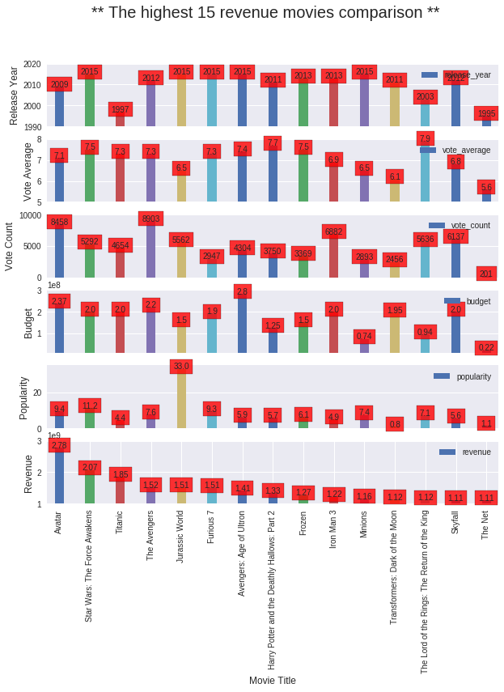

```python
x = df_sorted[0:15].original_title.values.tolist()

fig, ax = plt.subplots(6, 1)
fig.suptitle('** The highest 15 revenue movies comparison **', fontsize=20)
plt.style.use('seaborn')

ax=plt.subplot(6,1, 1)
ax.axes.get_xaxis().set_visible(False)
ax=df_sorted[0:15].plot(x="original_title",y="release_year",figsize=(10, 10),kind='bar',ax=ax, width=0.3)
ax.set_ylabel("Release Year",fontsize=12)
ax.set_ylim(1990 , 2020)
y=df_sorted[0:15].release_year.values.tolist()
addlabels(x, y)

ax=plt.subplot(6,1,2)
ax.axes.get_xaxis().set_visible(False)
ax=df_sorted[0:15].plot(x="original_title",y="vote_average",figsize=(10, 10),kind='bar',ax=ax, width=0.3)
ax.set_ylabel("Vote Average",fontsize=12)
ax.set_ylim(5 , 8)
y=df_sorted[0:15].vote_average.values.tolist()
addlabels(x, y)

ax=plt.subplot(6,1, 3)
ax.axes.get_xaxis().set_visible(False)
ax=df_sorted[0:15].plot(x="original_title",y="vote_count",figsize=(10, 10),kind='bar',ax=ax, width=0.3)
ax.set_ylabel("Vote Count",fontsize=12)
ax.set_ylim(0 , 10000)
y=df_sorted[0:15].vote_count.values.tolist()
addlabels(x, y)

ax=plt.subplot(6,1, 4)
ax.axes.get_xaxis().set_visible(False)
ax=df_sorted[0:15].plot(x="original_title",y="budget",figsize=(10, 10),kind='bar',ax=ax, width=0.3)
ax.set_ylabel("Budget",fontsize=12)
ax.set_ylim(1e7 , 3e8)
y=df_sorted[0:15].budget.values.tolist()
addlabels_1e8(x, y)

ax=plt.subplot(6,1, 5)
ax.axes.get_xaxis().set_visible(False)
ax=df_sorted[0:15].plot(x="original_title",y="popularity",figsize=(10, 10),kind='bar',ax=ax, width=0.3)
ax.set_ylabel("Popularity",fontsize=12)
ax.set_ylim(0 , 35)
y=df_sorted[0:15].popularity.values.tolist()
addlabels_1e0(x, y)

ax=plt.subplot(6,1, 6)
ax=df_sorted[0:15].plot(x="original_title",y="revenue",figsize=(10, 10),kind='bar',ax=ax, width=0.3)
ax.set_ylabel("Revenue",fontsize=12)
ax.set_xlabel("Movie Title",fontsize=12)
ax.set_ylim(1e9 , 3e9)
y=df_sorted[0:15].revenue.values.tolist()
addlabels_1e9(x, y)


plt.savefig('first 15th movies revenue compare.jpg')
```

### 3.1.3 - What kinds of properties are associated with movies that have high revenues?

```python
df.info()
```

```
<class 'pandas.core.frame.DataFrame'>
Int64Index: 10865 entries, 0 to 10865
Data columns (total 13 columns):
popularity              10865 non-null float64
budget                  10865 non-null int64
revenue                 10865 non-null int64
original_title          10865 non-null object
cast                    10789 non-null object
director                10821 non-null object
runtime                 10865 non-null int64
genres                  10842 non-null object
production_companies    9835 non-null object
release_date            10865 non-null object
vote_count              10865 non-null int64
vote_average            10865 non-null float64
release_year            10865 non-null int64
dtypes: float64(2), int64(5), object(6)
memory usage: 1.2+ MB
```

#### Research Question 6 : What kinds of properties are associated with movies that have high revenues?

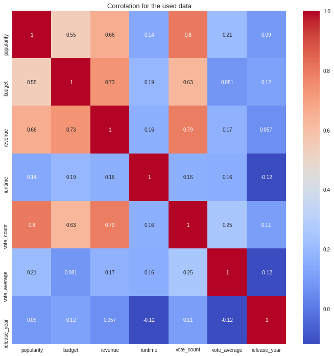

```python
# Correlation matrix
boston_corr = df.corr()

plt.figure (figsize=(12,12))
ax = sns.heatmap(boston_corr, annot = True, cmap = 'coolwarm')
ax.set_title("Corrolation for the used data",fontsize=13)
plt.savefig('df corr.jpg')
```

#### From the previous analysis

1- There is corrolation between the populatity and the revenue , so popularity is **effective**

2- There is weak corrolation between the vote average and the revenue , so vote average is **not effective**

3- There is positive and high corrolation between the budget and the revenue, but not mandatory the movies with high budget has high revenue

5- There is positive and high corrolation between the vote count and the revinue, **the more vote count , the more revenue movies**

### 3.1.4 - Highest Popularity Movies per Years

```python
year_list = np.array(df['release_year'])
year_list = np.unique(year_list)
#print(year_list)
```

```python
movie_name=[]
grouped  = df.groupby('release_year')
for year in year_list:
    value = grouped.get_group(year).popularity.max()
    #print(year,"  :  ",df.original_title[(df['popularity']==value.item()) & (df['release_year']==year)].values[0])
    #movie_name.append(df.original_title[(df['popularity']==value.item()) & (df['release_year']==year)].values[0])
    movie_name.append(df.original_title[(df['popularity']==value) & (df['release_year']==year)].values[0])

df1 =  pd.DataFrame({'Year':year_list,
                     'Movie_Name':movie_name})
df1
```

|  | Year | Movie_Name |
| --- | --- | --- |
| 0 | 1960 | Psycho |
| 1 | 1961 | One Hundred and One Dalmatians |
| 2 | 1962 | Dr. No |
| 3 | 1963 | From Russia With Love |
| 4 | 1964 | Goldfinger |
| 5 | 1965 | Thunderball |
| 6 | 1966 | How the Grinch Stole Christmas! |
| 7 | 1967 | The Jungle Book |
| 8 | 1968 | 2001: A Space Odyssey |
| 9 | 1969 | On Her Majesty's Secret Service |
| 10 | 1970 | The Aristocats |
| 11 | 1971 | A Clockwork Orange |
| 12 | 1972 | The Godfather |
| 13 | 1973 | Robin Hood |
| 14 | 1974 | The Godfather: Part II |
| 15 | 1975 | One Flew Over the Cuckoo's Nest |
| 16 | 1976 | Taxi Driver |
| 17 | 1977 | Star Wars |
| 18 | 1978 | Grease |
| 19 | 1979 | Alien |
| 20 | 1980 | The Empire Strikes Back |
| 21 | 1981 | Raiders of the Lost Ark |
| 22 | 1982 | Blade Runner |
| 23 | 1983 | Return of the Jedi |
| 24 | 1984 | The Terminator |
| 25 | 1985 | Back to the Future |
| 26 | 1986 | Aliens |
| 27 | 1987 | Predator |
| 28 | 1988 | Die Hard |
| 29 | 1989 | The Little Mermaid |
| 30 | 1990 | Total Recall |
| 31 | 1991 | Beauty and the Beast |
| 32 | 1992 | Reservoir Dogs |
| 33 | 1993 | Groundhog Day |
| 34 | 1994 | Pulp Fiction |
| 35 | 1995 | Se7en |
| 36 | 1996 | Independence Day |
| 37 | 1997 | Eddie Izzard: Glorious |
| 38 | 1998 | The Truman Show |
| 39 | 1999 | Fight Club |
| 40 | 2000 | Gladiator |
| 41 | 2001 | The Lord of the Rings: The Fellowship of the Ring |
| 42 | 2002 | The Lord of the Rings: The Two Towers |
| 43 | 2003 | The Lord of the Rings: The Return of the King |
| 44 | 2004 | Harry Potter and the Prisoner of Azkaban |
| 45 | 2005 | Harry Potter and the Goblet of Fire |
| 46 | 2006 | Underworld: Evolution |
| 47 | 2007 | Pirates of the Caribbean: At World's End |
| 48 | 2008 | The Dark Knight |
| 49 | 2009 | Avatar |
| 50 | 2010 | Inception |
| 51 | 2011 | Underworld: Endless War |
| 52 | 2012 | The Avengers |
| 53 | 2013 | Frozen |
| 54 | 2014 | Interstellar |
| 55 | 2015 | Jurassic World |